# práctica 4

[figure not shown]

### Práctibca 4: Matriculaciones

#### Predicción de series temporales

14 de diciembre de 2021

##### Autores:

- González Díaz, Guillermo
- Gómez Rivas, Alejandro

El objetivo es predecir las matriculaciones de noviembre y diciembre de 2021 con los datos dados.

Hemos decidido quedarnos con los datos desde 2011 en adelante, una vez superada la crisis de 2008. Aparte, la economía de hoy ha cambiado mucho respecto a la del siglo pasado

```python
# Importamos las librerias que utilizaremos en el trabajo:
import pandas as pd
import numpy as np
import matplotlib.pyplot as plt
import seaborn as sns
import statsmodels.api as sm
import warnings
from sktime.forecasting.arima import AutoARIMA
from statsmodels.graphics import tsaplots
from sktime.utils.plotting import plot_correlations
from statsmodels.tsa.seasonal import seasonal_decompose
from sktime.transformations.series.boxcox import LogTransformer
from sktime.forecasting.model_selection import temporal_train_test_split
from sktime.performance_metrics.forecasting import mean_absolute_percentage_error
from sktime.transformations.series.difference import Differencer
from sktime.utils.plotting import plot_series
from sktime.forecasting.ets import AutoETS
warnings.filterwarnings('ignore')
```

```python
# Leemos nuestros datos:
mat = pd.read_excel('Matriculaciones.xlsx')
mat.head()
```

|  | periodos | matriculaciones |
| --- | --- | --- |
| 0 | 201101 | 54416 |
| 1 | 201102 | 67028 |
| 2 | 201103 | 88947 |
| 3 | 201104 | 72413 |
| 4 | 201105 | 79317 |

```python
# Convertimos en formato fecha
mat['periodos'] = pd.to_datetime(mat['periodos'], format='%Y%m')
# Creamos índice = fecha
mat = mat.set_index('periodos')
mat.head()
```

| periodos | matriculaciones |
| --- | --- |
| 2011-01-01 | 54416 |
| 2011-02-01 | 67028 |
| 2011-03-01 | 88947 |
| 2011-04-01 | 72413 |
| 2011-05-01 | 79317 |

Lo primeor que llama la atención es el período covid que tendremos que intervenir. Lo segundo que llama la atención es la estacionalidad anual, encontrándonos mínimos en todas mitades del año.

Respecto a la tendencia, observábamos una tendencia alcista hasta el covid, una caída, y ahora una pequeña recuperación.

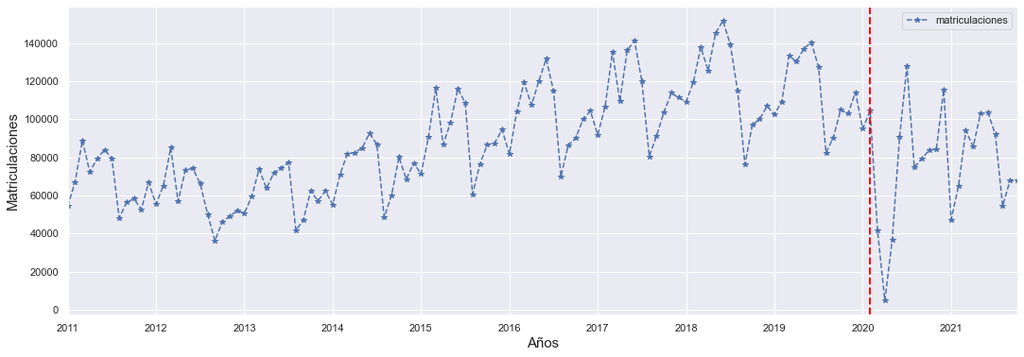

```python
# Ploteamos nuestra serie temporal:
sns.set(rc={'figure.figsize':(18, 6)})
fig = mat.plot(marker='*', linestyle='--')
fig.set_ylabel('Matriculaciones', fontsize = 15)
fig.axvline('2020-02-01', color = 'red', linestyle= '--', linewidth= 2)
fig.set_xlabel('Años', fontsize = 15);
```

#### Analizamos tendencia y estacionalidad:

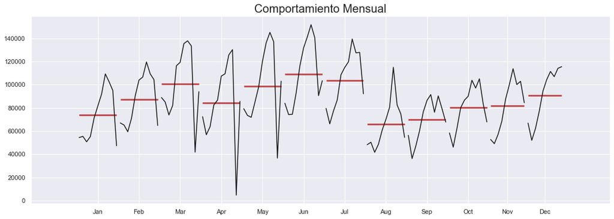

```python
# Componente estacional mensual:
ax = plt.gca()
sm.graphics.tsa.month_plot(mat['matriculaciones'], ax = ax)
ax.set_title('Comportamiento Mensual', fontsize = 20)
```

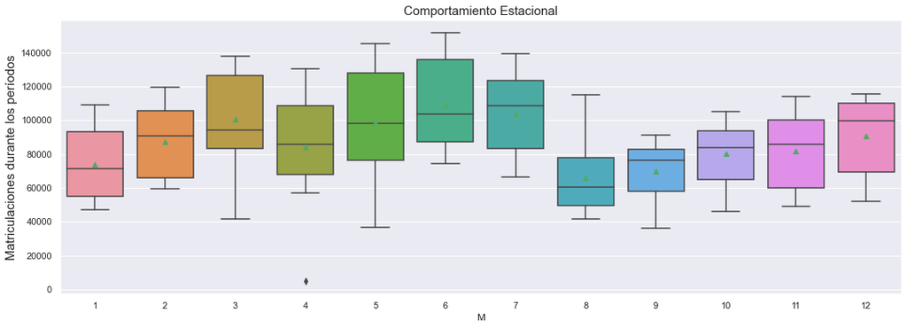

```python
# Pasamos a realizar un boxplot mensual para estudiar las distribuciones:
mat['M'] = mat.index.month
sns.boxplot(data = mat, x = 'M', y='matriculaciones', showmeans=True)
ax = plt.gca()
ax.set_ylabel('Matriculaciones durante los períodos', fontsize = 15)
ax.set_title('Comportamiento Estacional', fontsize = 15)
```